# PSTAT 126 Project

Jeff Shen

2023-04-27

## Introduction

In this project, we will analyze the relationship between income and education using the income.csv dataset. Rather than simply comparing income levels and education levels, we will aggregate the data by calculating the percentage of individuals with income >50k for each education level. This will allow us to create a quantitative variable for the proportion of individuals in each education level who earn a high income, which we can then use to explore the relationship between education and income. The dataset of interest comes from the UCI Machine Learning Repository and is available on Kaggle as well at: https://www.kaggle.com/datasets/uciml/adult-census-income. It contains information about individuals from the 1994 Census database, including demographic variables such as age, education, marital status, occupation, and more.

The variable of interest for this analysis is the income column, and we will be using a simple linear regression model to examine its relationship with education.

## Hypotheses

Our objective is to investigate the relationship between education and income among individuals in the 1994 Census database by aggregating the data to calculate the percentage of individuals with income >50k for each education level. We aim to determine whether there is a positive linear relationship between education and the proportion of individuals with high income.

Null hypothesis: There is no significant positive linear relationship between education and the proportion of individuals with high income in the 1994 Census database. The beta coefficient for education (β1) in a linear regression model predicting the proportion of individuals with high income is equal to zero.

$$H_0: \beta_1 = 0$$

Alternative hypothesis: There is a significant positive linear relationship between education and the proportion of individuals with high income in the 1994 Census database, with higher levels of education associated with a higher proportion of individuals with high income. The beta coefficient for education (β1) in a linear regression model predicting the proportion of individuals with high income is greater than zero.

$$H_a: \beta_1 > 0$$

We can test these hypotheses using a linear regression model and examining the p-value associated with the beta coefficient for education. If the p-value is less than our chosen significance level (typically 0.05), we can reject the null hypothesis and conclude that there is evidence of a positive linear relationship between education and the proportion of individuals with high income.

## Checking the Assumptions for Linear Regression

```r
income_data <- read.csv("~/Desktop/adult.csv")
head(income_data)
```

```
##   age workclass fnlwgt    education education.num marital.status
## 1  90         ?  77053      HS-grad             9        Widowed
## 2  82   Private 132870      HS-grad             9        Widowed
## 3  66         ? 186061 Some-college            10        Widowed
## 4  54   Private 140359      7th-8th             4       Divorced
## 5  41   Private 264663 Some-college            10      Separated
## 6  34   Private 216864      HS-grad             9       Divorced
##          occupation  relationship  race    sex capital.gain capital.loss
## 1                 ? Not-in-family White Female            0         4356
## 2   Exec-managerial Not-in-family White Female            0         4356
## 3                 ?     Unmarried Black Female            0         4356
## 4 Machine-op-inspct     Unmarried White Female            0         3900
## 5    Prof-specialty     Own-child White Female            0         3900
## 6     Other-service     Unmarried White Female            0         3770
##   hours.per.week native.country income
## 1             40  United-States  <=50K
## 2             18  United-States  <=50K
## 3             40  United-States  <=50K
## 4             40  United-States  <=50K
## 5             40  United-States  <=50K
## 6             45  United-States  <=50K
```

[figure not shown]

[figure not shown]

[figure not shown]

```r
# Perform linear regression
lm_fit <- lm(prop_over_50k ~ education_num, data = income_summary)
summary(lm_fit)
```

```
##
## Call:
## lm(formula = prop_over_50k ~ education_num, data = income_summary)
##
## Residuals:
##      Min       1Q   Median       3Q      Max
## -0.13377 -0.10231 -0.02089  0.08306  0.19893
##
## Coefficients:
##                Estimate Std. Error t value Pr(>|t|)
## (Intercept)   -0.166844   0.060233  -2.770    0.015 *
## education_num  0.046819   0.006229   7.516 2.81e-06 ***
## ---
## Signif. codes:  0 '***' 0.001 '**' 0.01 '*' 0.05 '.' 0.1 ' ' 1
##
## Residual standard error: 0.1149 on 14 degrees of freedom
## Multiple R-squared:  0.8014, Adjusted R-squared:  0.7872
## F-statistic: 56.49 on 1 and 14 DF,  p-value: 2.809e-06
```

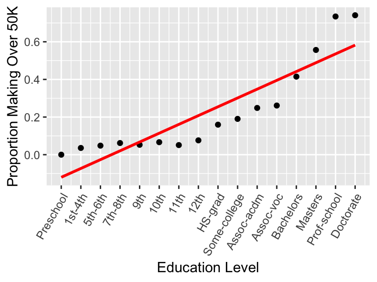

```r
# Plot trend line
ggplot(income_summary, aes(x = education_num, y = prop_over_50k)) +
  geom_point() +
  geom_smooth(method = "lm", se = FALSE, color = "red") +
  labs(x = "Education Level", y = "Proportion Making Over 50K") +
  scale_x_continuous(breaks = c(1:length(edu_levels)), labels = edu_levels) +
  theme(axis.text.x = element_text(angle = 60, hjust = 1),
    plot.title = element_text(size = 11, hjust = 0.5, vjust = 1.5))
```

```r
beta_1 <- coef(lm_fit)[2]
cat("beta_1 coefficient: ", beta_1, "\n")
```

```
## beta_1 coefficient:  0.04681908
```